# Project7_UdacityDAND

### 4.12 Correlation Matrix

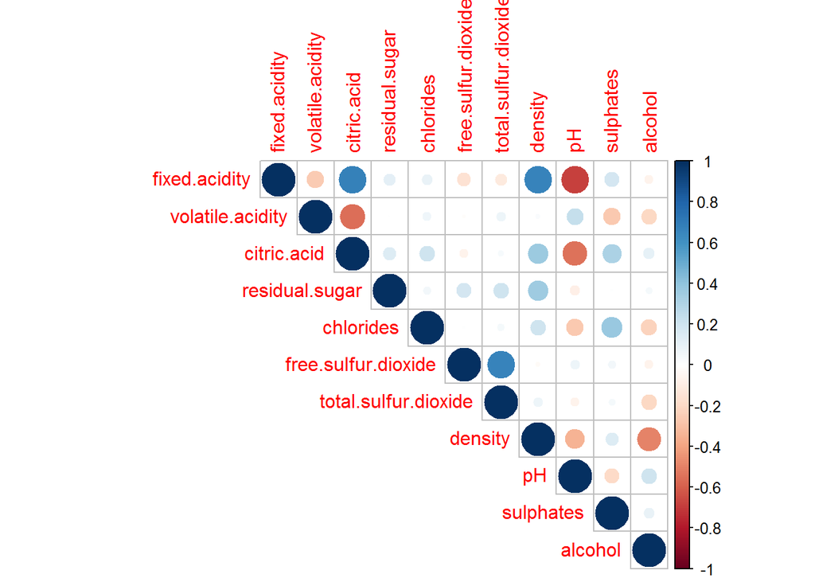

```r
correlation_matrix <- cor(wine_reds[, 1:11])
corrplot(correlation_matrix, type = 'upper')
```

**It seems that we have many interesting pairs to invistigate about** :

1- Fixed Acidity vs Citric Acid  
2- Fixed Acidity vs density  
3- Fixed Acidity vs pH  
5- Citric Acid vs pH  
6- Total Sulfur Dioxide vs Free Sulfur Dioxide  
7- Density vs Alcohol.

**Again, to make this project applies for good coding practices, i will create a function which i will use in Plot attributes.**

```r
# Function to plot a scatter plot of two varaibles versuseach other.
plot_var1_vs_var2 <- function(variable1, variable2) {
  return (ggplot(aes_string(x = variable1, y = variable2), data = wine_reds) +
    geom_point(alpha = 1/4, position = position_jitter(width = 0)))
}
```

#### 4.12.1 Fixed Acidity vs Citric Acid

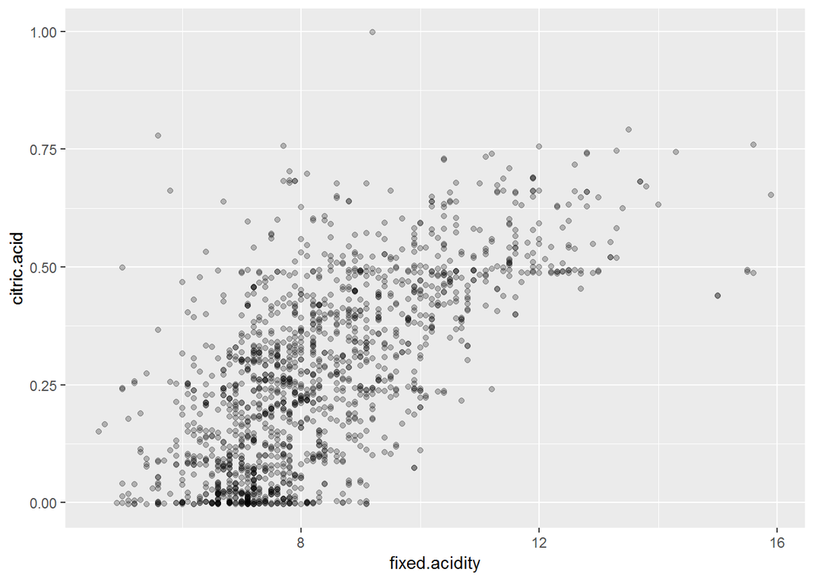

```r
##Plot Fixed Acidity values vs Citric Acid values.
plot_var1_vs_var2('fixed.acidity','citric.acid')
```

And the value of the correlation coefficient between these two variables is:

```r
##Use Cor funtion to get the actual value of correlation coefficient between these two variables.
cor(wine_reds$fixed.acidity, wine_reds$citric.acid)
```

```
## [1] 0.6717034
```

It looks like that higher concentration of Fixed Density leads to higher Citric Acid values too.

#### 4.12.2 Fixed Acidity vs Density

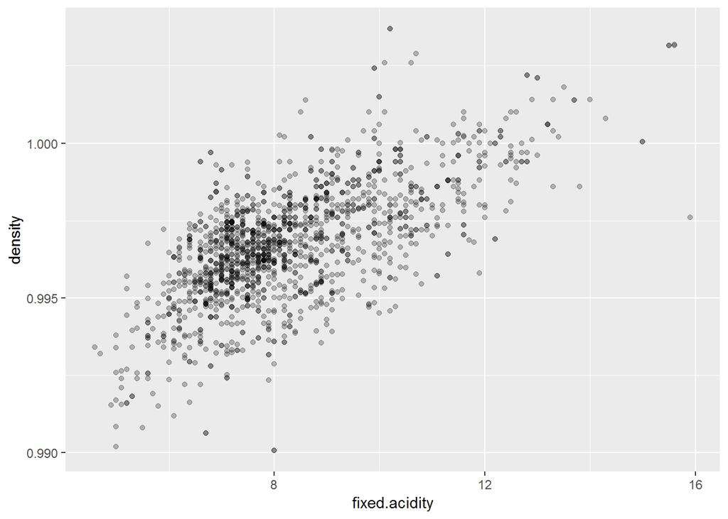

```r
##Plot Fixed Acidity values vs Density values.
plot_var1_vs_var2('fixed.acidity','density')
```

And the value of the correlation coefficient between these two variables is:

```r
##Use Cor funtion to get the actual value of correlation coefficient between these two variables.
cor(wine_reds$fixed.acidity, wine_reds$density)
```

```
## [1] 0.6680473
```

The higher concentration of Fixed Density is, the higher Density values are too.

#### 4.12.3 Fixed Acidity vs pH

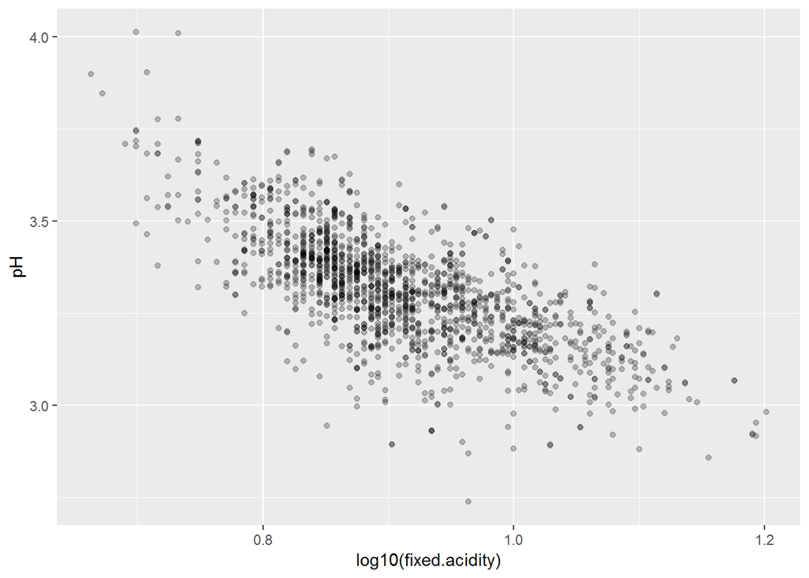

```r
##Plot Fixed Acidity values vs Density values.
plot_var1_vs_var2('log10(fixed.acidity)','pH')
```

```r
##Use Cor funtion to get the actual value of correlation coefficient between these two variables.
cor(log10(wine_reds$fixed.acidity), wine_reds$pH)
```

```
## [1] -0.7063602
```

Due to the scale of pH is logarithmic, so i transformed fixed Acidity to Log10(Fixed acidity). Thus, the correlation between these two variables are -0.706. Hence, the higher fixed acidity concentration is, the lower pH values are.

#### 4.12.4 Volatile Acidity vs Citric Acid

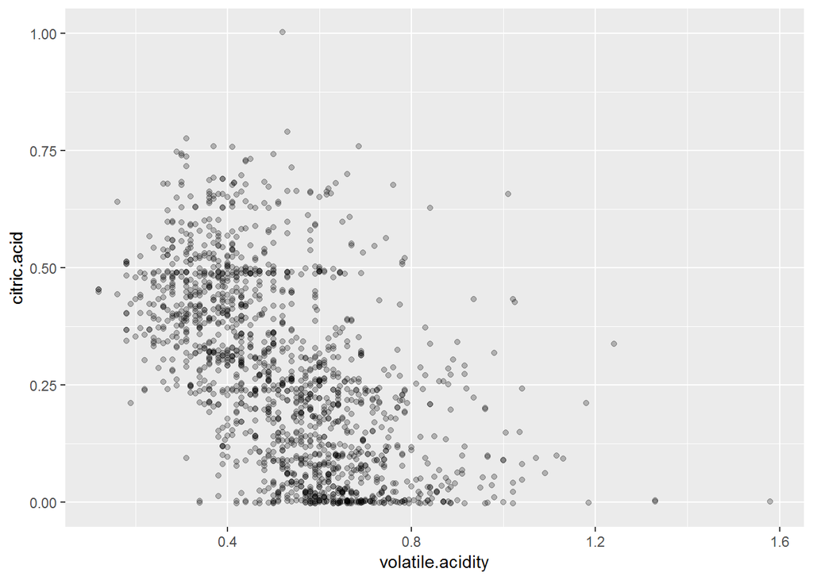

```r
##Plot Volatile Acidity values vs Citric Acid values.
plot_var1_vs_var2('volatile.acidity', 'citric.acid')
```

```r
##Use Cor funtion to get the actual value of correlation coefficient between these two variables.
cor(wine_reds$volatile.acidity, wine_reds$citric.acid)
```

```
## [1] -0.5524957
```

#### 4.12.5 Citric Acid vs pH

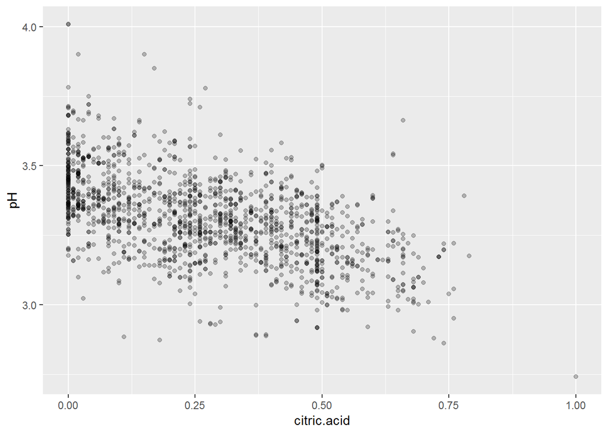

```r
##Plot Citric Acid values vs pH values.
plot_var1_vs_var2('citric.acid','pH')
```

```r
##Use Cor funtion to get the actual value of correlation coefficient between these two variables.
cor(wine_reds$citric.acid, wine_reds$pH)
```

```
## [1] -0.5419041
```

The higher Citiric Acid concentration is, the lower pH values are.

#### 4.12.6 Total Sulfur Dioxide vs Free Sulfur Dioxide

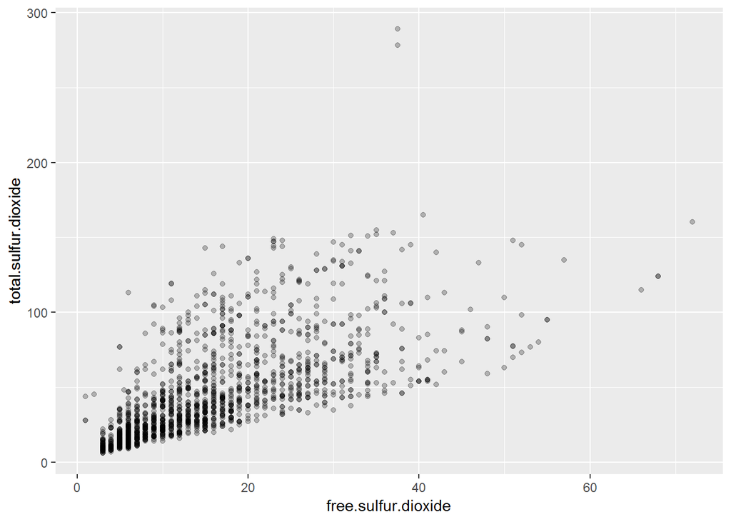

```r
##Plot total Sulfur Dioxide values vs Free Sulfur Dioxide values.
plot_var1_vs_var2('free.sulfur.dioxide', 'total.sulfur.dioxide')
```

```r
##Use Cor funtion to get the actual value of correlation coefficient between these two variables.
cor(wine_reds$total.sulfur.dioxide, wine_reds$free.sulfur.dioxide)
```

```
## [1] 0.6676665
```

The Free Sulfur Dioxide is part of Total Sulfur Dioxide.

#### 4.12.7 Density vs Alcohol

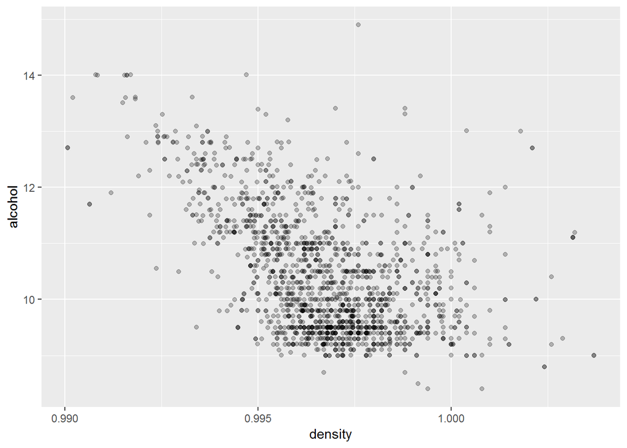

```r
##Plot Density values vs alcohol values.
plot_var1_vs_var2('density', 'alcohol')
```

```r
##Use Cor funtion to get the actual value of correlation coefficient between these two variables.
cor(wine_reds$density, wine_reds$alcohol)
```

```
## [1] -0.4961798
```

The higher level of Alcohol is, the lower the density is.

## 5- Bivariate Analysis

**Talk about some of the relationships you observed in this part of the investigation. How did the feature(s) of interest vary with other features in the dataset?**

- Quality is positively correlated with Alcohol, Citric Acid and Sulphates.
- Quality is negatively correlated with Chlorides, Density, Volatile Acidity and pH.

**Did you observe any interesting relationships between the other features (not the main feature(s) of interest)?**

- Total sulfur dioxide and free sulfur dioxide are positively correlated because total sulfur dioxide includes free sulfur dioxide.
- Fixed acidity and pH are negatively correlated because higher concentration of fixed acidity makes the wine more acidic, therefore the wine has a lower pH.

**What was the strongest relationship you found?**

The stronget relationship i have already found is the raltaionship between Volatile Acidity and Quality.

## 6- Multivariate Exploration

In this section, I will first look at how Quality, volatile Acidity with one input variable are related together.

**To make this project applies for good coding practices, i will create a function which i will use in Plot attributes.**

```r
##Function to plot a scatter plot of variable2 vs variable1 colored by quality
plot_multi <- function(variable1, variable2) {
  ggplot(aes_string(x = variable1, y = variable2, color = 'quality'), data = wine_reds) +
    geom_jitter(alpha = 1/2) +
    scale_color_brewer(type = 'div')
}
```

#### 6.1 Quality vs Volatile Acidity and Alcohol

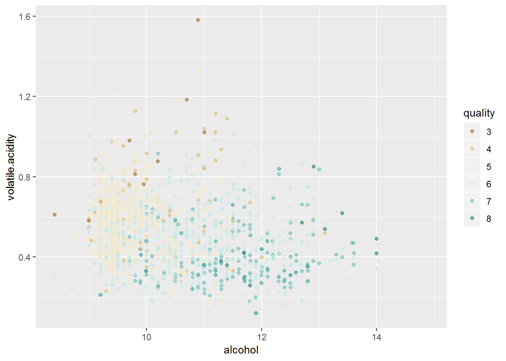

```r
##Plot Alcohol values with volatile Acidity values color by Quality
plot_multi('alcohol', 'volatile.acidity')
```

- **High quality wines** tend to have **low volatile acidity** and **high alcohol** “lower right corner”.
- **Low quality wines** tend to have **high volatile acidity** and **low alcohol** “upper left corner”.

#### 6.2 Quality vs Volatile Acidity and Citric Acid

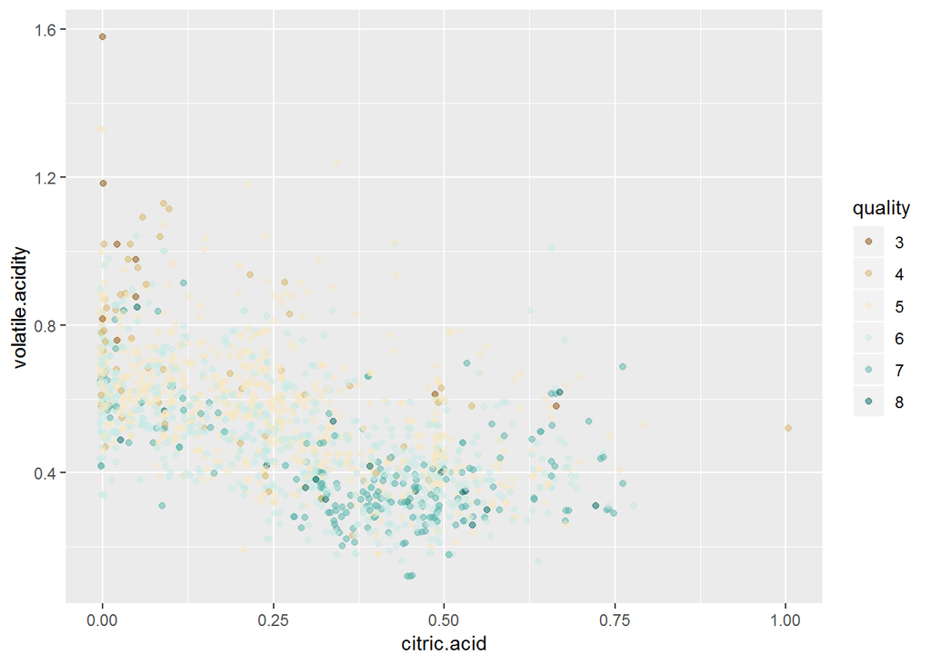

```r
##Plot Citric Acid values with volatile Acidity values color by Quality
plot_multi('citric.acid', 'volatile.acidity')
```

#### 6.3 Quality vs Volatile Acidity and Sulphates

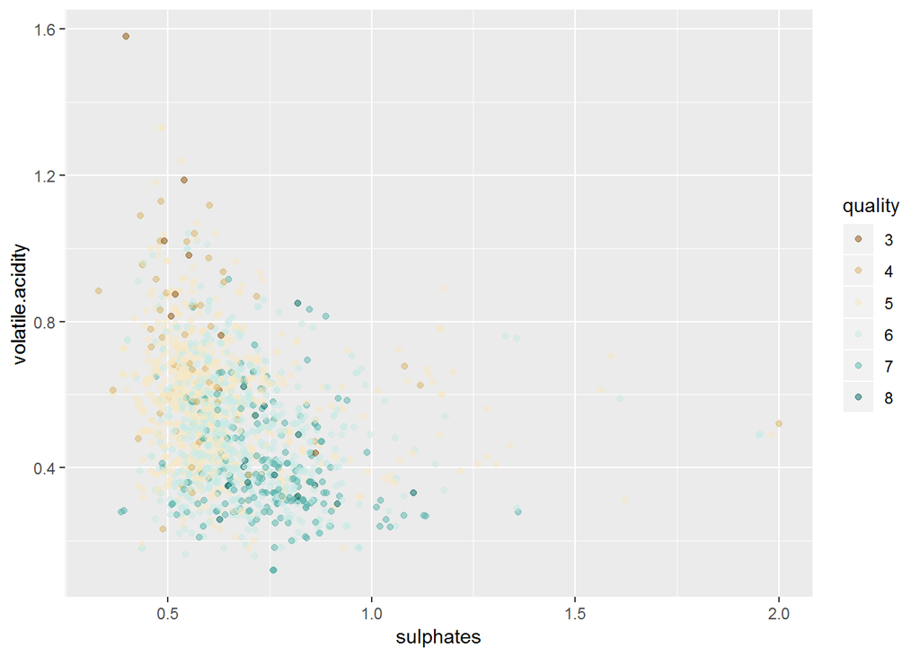

```r
##Plot Citric Acid values with volatile Acidity values color by Quality
plot_multi('sulphates', 'volatile.acidity')
```

- **High quality wines** tend to have **low Volatile Acidity** and **High sulphates** “lower right corner”.
- **Low quality wines** tend to have **high Volatile Acidity** and **Low sulphates** “upper left corner”.

#### 6.4 Quality vs Volatile Acidity and Density

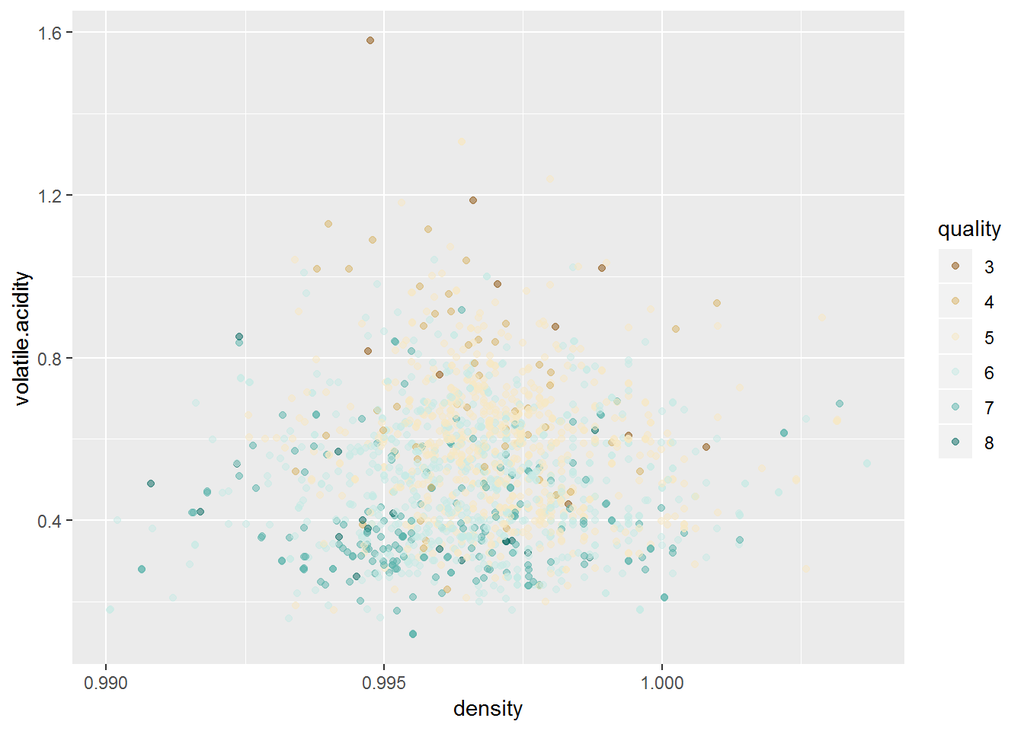

```r
##Plot Density values with volatile Acidity values color by Quality
plot_multi('density', 'volatile.acidity')
```

- **High quality wines** tend to have **low volatile acidity** and **low density** “lower left corner”.
- **Low quality wines** tend to have **high volatile acidity** and **high density** “upper right corner”.

#### 6.5 Quality vs Volatile Acidity and pH

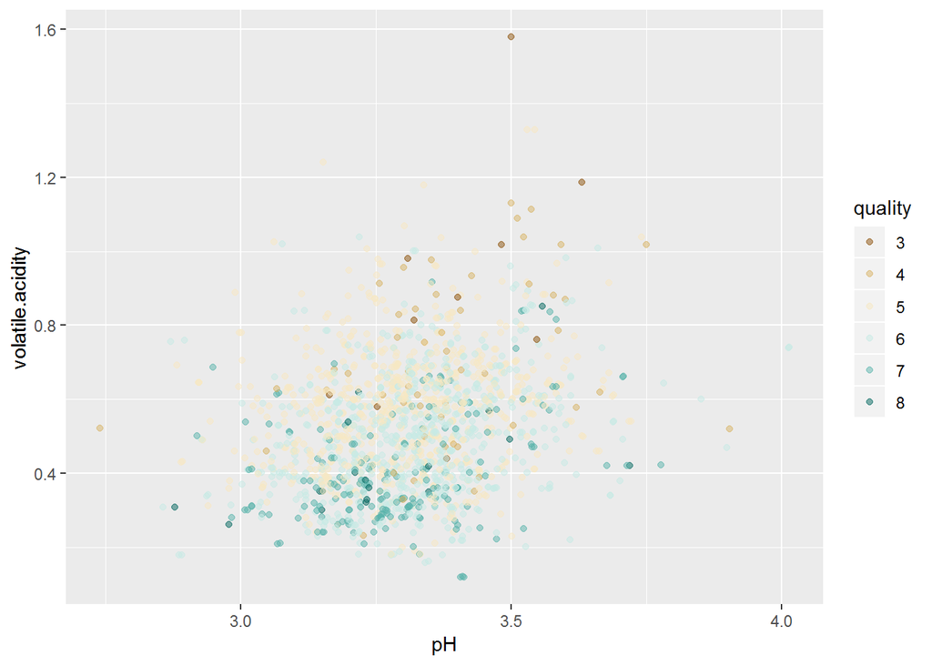

```r
##Plot pH values with volatile Acidity values color by Quality
plot_multi('pH', 'volatile.acidity')
```

- **High quality wines** tend to have **low volatile acidity** and **low pH**. “lower left corner”
- **Low quality wines** tend to have **high volatile acidity** and **high pH**. “upper right corner”

## 7- Multivariate Analysis

**Talk about some of the relationships you observed in this part of the investigation. Were there features that strengthened each other in terms of looking at your feature(s) of interest?**

By combaring the strongest relationship mentioned in Bivariate section, Volatile Acidity with Quality, with one of the other attributes (Citric Acid, Alcohol, Sulphates, Density and pH), we can easily differentiate between the high quality wine and the low quality wine.

**Were there any interesting or surprising interactions between features?**

We can notice by looking at **Quality vs Volatile Acidity and pH** that **High quality wines** tend to have **low volatile acidity** and **low pH**, and because of Fixed acidity and pH are negatively correlated with each other, hence, **High quality wines** tend to have **low Volatile Acidity** and **high Fixed Acidity**.

## 8- Final Plots

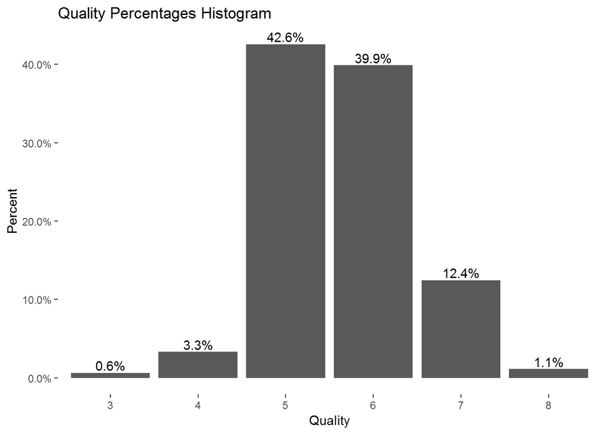

```r
ggplot(aes(x = quality), data = wine_reds) +
  geom_bar(aes(y = (..count..)/sum(..count..))) +
  geom_text(aes(y = ((..count..)/sum(..count..)),
            label = scales::percent((..count..)/sum(..count..))),
            stat = "count",
            vjust = -0.25) +
  xlab('Quality') +
  ylab('Percent') +
  scale_y_continuous(labels = scales::percent) +
  ggtitle('Quality Percentages Histogram') +
  theme(panel.grid.major = element_blank(),
        panel.grid.minor = element_blank(),
        panel.background = element_blank())
```

All quality values are ranging from 0 to 10, however, all red wines in this dataset have quality values between 3 and 8. additionally, most of the red wines have quality 5 or 6, meanwhile the qualities 3, 4 and 8 have barely wines which make the dataset not well balanced. Thus, i want to conclude my exploratory analysis with plot showing what are the percentage of each quality level in this dataset.

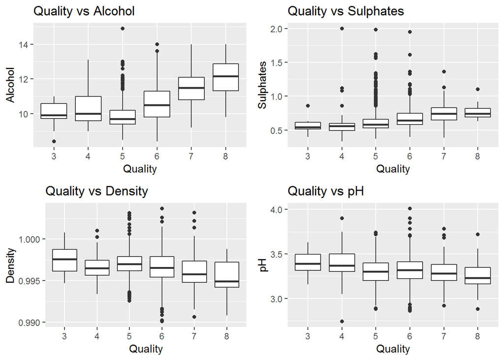

```r
q1 <- ggplot(aes(x = quality, y = alcohol), data = wine_reds) +
      geom_boxplot() +
      xlab("Quality") +
      ylab("Alcohol") +
      ggtitle("Quality vs Alcohol")


q2 <- ggplot(aes(x = quality, y = sulphates), data = wine_reds) +
      geom_boxplot() +
      xlab("Quality") +
      ylab("Sulphates") +
      ggtitle("Quality vs Sulphates")


q3 <- ggplot(aes(x = quality, y = density), data = wine_reds) +
      geom_boxplot() +
      xlab("Quality") +
      ylab("Density") +
      ggtitle("Quality vs Density")

q4 <- ggplot(aes(x = quality, y = pH), data = wine_reds) +
      geom_boxplot() +
      xlab("Quality") +
      ylab("pH") +
      ggtitle("Quality vs pH")



grid.arrange(q1,q2,q3,q4,ncol = 2)
```

We can see 4 box plot visulaizations comparing the quality attribute to 4 different input attributes. Here we can see easily that the qulaity attribute is positivley increasing with Alcohol and Sulphates, on the contrary, the Quality attribute is negetively correlated with Density and pH.

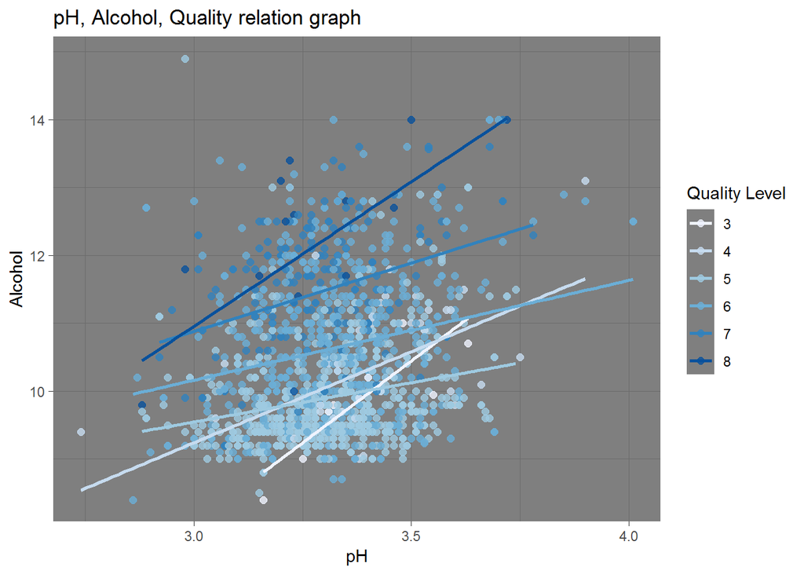

```r
ggplot(aes(x=pH, y=alcohol, color=factor(quality)), data = wine_reds) +
      geom_point(alpha = 0.8, size = 2) +
      geom_smooth(method = "lm", se = FALSE,size=1)  +
      scale_color_brewer(type='seq', guide=guide_legend(title='Quality Level')) +
      xlab("pH") +
      theme_dark() +
      ylab("Alcohol") +
      labs(color = "Quality") +
      ggtitle("pH, Alcohol, Quality relation graph")
```

Here we can note many relations. We can clearly see that whiter colors are below in the visualization, while darker colors are above which it translates the follwoing:

- Qulaity and Alcohol has a proportioal relation betwenn each other.
- PH does not seems to have any specific trend with the Quality level.

**NOTE:** pH: is how acidic or basic a wine is on a scale from 0 (very acidic) to 14 (very basic); most wines are between 3-4 on the pH scale.

## 9- Reflection

The red wine dataset contains information on 1599 wine samples with 12 variables from around 2009. During my analysis, i was concentrated on showing the relationship of a number of red wine attributes with the quality rankings of different wines. Using functions to easily plot different and many attributes was also very helpful in this report. Using boxplots and histograms made my analysis very illustrative and easy to read. Using the insights from correlation coefficients calculated during the Bivariate Exploration section,the Quality vs Volatile Aciditiy was the most promising relationship, that’s why i used Volatile Acidity as the fixed attribute in the Multivariate Exploration section.

A way to improve this report is by building a statistical model to predict the red wine quality, with providing new attributes such as Price, Color and Smell.